# Cross-Price Elasticity

Calculating Cross-Price Elasticity and some tricks in R.

Raise or lower the price? How much money could we actually make? How sensitive are people towards price change?

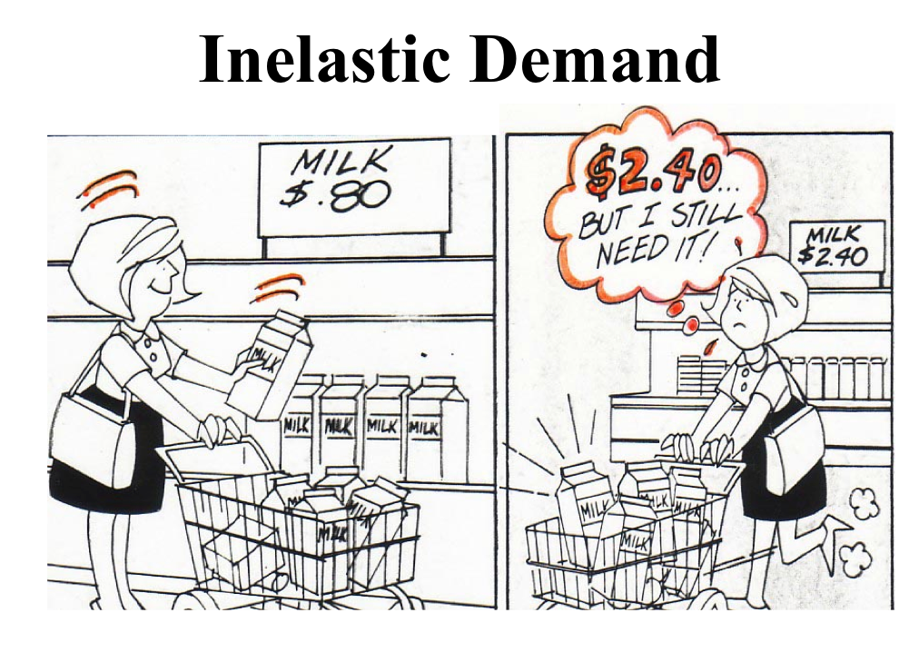

One way to figure this out is [dynamic pricing](https://tykiww.github.io/2018-05-05-Dynamic-Chocolate-Pricing/). However, there are simpler methods especially when you know how to run a regression. Let’s download the UCI retail dataset to see what we can discover.

```r
library(tidyverse)
library(caret)
library(readxl)
```

Here is a small sidenote.

Reading in from Excel is usually a simple thing, usually we just find the file in our working directory and read in the path.

```r
path <- "https://github.com/tykiww/projectpage/raw/master/datasets/UCI-Retail/UCI-Retail.xlsx"
# read_excel(path)
gc()
```

[output not shown]

However, readxl does not actually work for reading in from online. To do so, we must specify a temporary location to store a download.

```r
temp <- tempfile(fileext = ".xlsx")
download.file(path, destfile = temp, model = 'wb')
retails <- read_excel(temp, sheet = 1) %>% as_tibble
```

There we go!

Now that we have our data read in, let’s pick an object from the data that has a high volume. The more information, the better.

```r
# quick clean
retail1 <- subset(retail, retail$UnitPrice > 0)
retail2 <- subset(retail1, retail1$Quantity > 0)
elast <- select(retail2, Quantity, UnitPrice)
# plot
rm(retail,retail1,retail2, temp, path)
gc() # garbage collection to clear out data.
```

Let’s jump straight in with the model. Typically, we may need to remove outliers and influential observations. However, for the sake of time and computational power, we will move right on.

There are many methods to calculate price elasticity using software. Since Elasticity is defined as the percent change in quantity divided by percentage change in price, we will be comparing 2 models using software. 1st is the most commonly seen, the level-level method. 2nd is the more ‘accurate’ model measuring the log-log elasticity. If you want a refresher on what elasticity is, click [here](https://courses.lumenlearning.com/boundless-economics/chapter/price-elasticity-of-demand/).

Method 1: (Level, Level) PE = (ΔQ/ΔP) * (P/Q)

This method is simple (so is the other one). We plot X and Y, then use the beta coefficient as the change in price and quantity. Aftwards, we will multiply P/Q by the most typical value. Since the data is both right skewed, we will use the median values.

```
## UnitPrice
## -5.991306
```

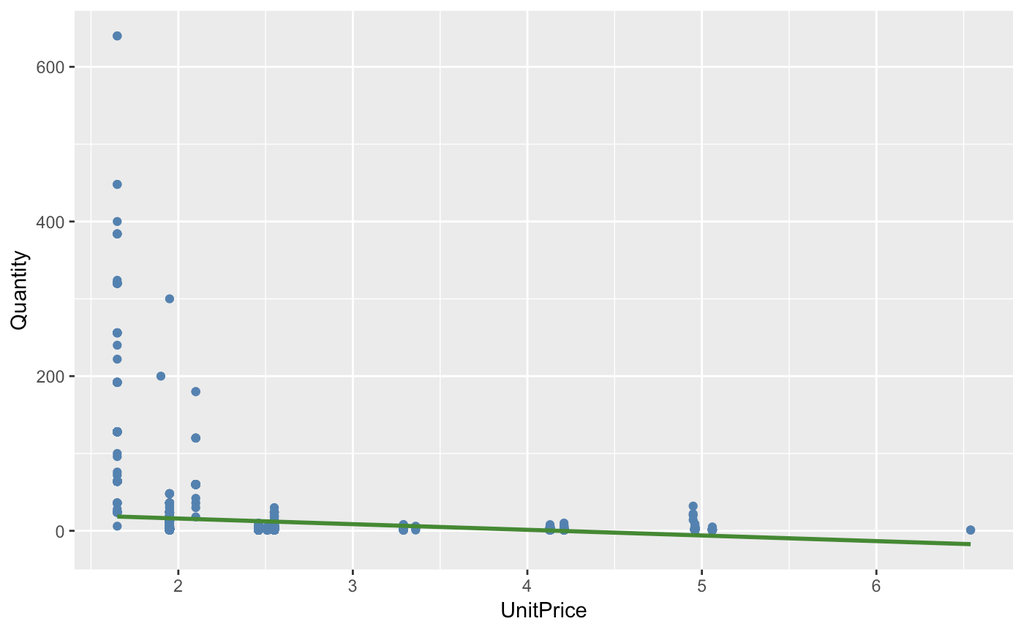

Maybe this data is not as useful in predicting. There may be two factors to this. 1. If we take a look at the labeled data, we notice that this data is comprised of retail throughout subsets of different countries (No wonder our values vary so much). and 2. There are clear outliers in the data when plotted and obvious skewing. Our log transformations should help.

Method 2: (Log, Log) Coefficient % Change output.

```
## log(UnitPrice)
##      -1.998695
```

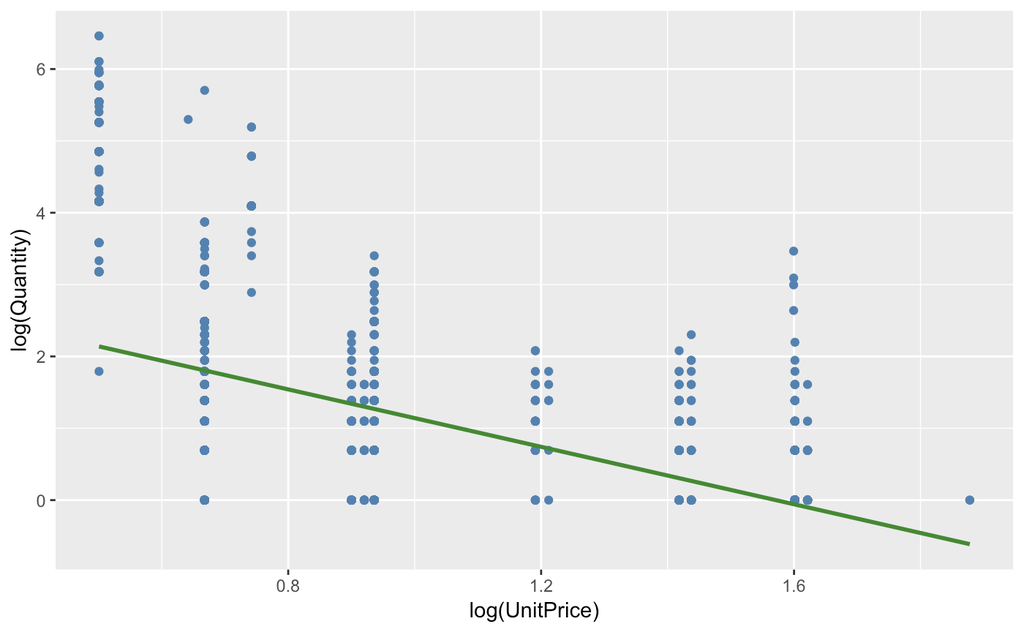

Let’s make some predictions. Our optimal Price formula is given by…

```
## Optimal Price = (Elasticity * Total Cost per Salad) / (1 + Elasticity)
```

If we were to assume that the store’s per-unit variable cost is around 1.95, we may model our elasticity as such..

```
## 3.902547
```

This is good news. By ensuring our price to be near 3.90 per lunchbox, we have optimized for this particular dataset. Of course, we had not breaken down seasonal trends, other factors, nor have we created an interval (use the `predict` function with the parameter interval as ‘prediction’ for that.). However we have been able to figure out the optimal price from our price elasticity of demand. Now the lunchbox business is back on track.

Hopefully this was a useful tool in determining your next pricing project!